# Supervised Learning

Le but de ce R markdown est d’établir un algorithme de machine learning capable de prédire le prix d’un véhicule de seconde main sur Craiglist.

Ce prédicteur permettra dans un contexte business, de suggérer un prix au client qui souhaite mettre en vente son véhicule sur notre site web. Ou bien, il pourrait permettre aux équipes métiers de déterminer si, en fonction de la prédiction et des règles de gestion, ils devraient mettre en avant ce véhicule sur le site web.

Nous avons donc créé et testé plusieurs modèles pour parvenir à cet objectif.

```r
#J'importe la base principale
data = read.csv("data/data_abe.csv", header = T, sep = ',', na.strings= "")
```

```r
#Je prends à part les variables QUANTITATIVES
data_num = data[,c(3,4,10,17,18)]
```

```r
#Je retire des variables inutiles
data = data[,-c(1,2,6)]
```

```r
#Je fusionne les variables QUANTITAVES et les DUMMIES.
data_final <- cbind(data_num,data_dummy)
```

```r
data_final = normalize(data_final, method = "standardize")
#Régression.
set.seed(1)
train.index <- sample(c(1:dim(data_final)[1]), dim(data_final)[1]*0.6)
valid.index <- setdiff(c(1:dim(data_final)[1]),train.index)
train.df <- data_final[train.index,]
valid.df <- data_final[train.index,]
lmm <- lm(price~.,data=data_final)
summary(lmm)
```

```
Call:
lm(formula = price ~ ., data = data_final)

Residuals:
    Min      1Q  Median      3Q     Max
-6.9919 -0.3667 -0.0763  0.2427 20.2070

Coefficients: (10 not defined because of singularities)
                                Estimate Std. Error  t value Pr(>|t|)
(Intercept)                    2.337e-15  1.126e-03    0.000 1.000000
year                           2.678e-01  1.363e-03  196.527  < 2e-16 ***
odometer                      -3.184e-01  1.246e-03 -255.572  < 2e-16 ***
lat                           -1.316e-02  1.183e-03  -11.118  < 2e-16 ***
long                          -7.219e-02  1.165e-03  -61.984  < 2e-16 ***
manufactureracura             -1.973e-02  1.699e-03  -11.616  < 2e-16 ***
`manufactureralfa-romeo`       3.574e-03  1.149e-03    3.109 0.001874 **
`manufactureraston-martin`     2.015e-02  1.151e-03   17.509  < 2e-16 ***
manufactureraudi              -1.183e-02  2.025e-03   -5.838 5.27e-09 ***
manufacturerbmw               -4.312e-02  2.594e-03  -16.625  < 2e-16 ***
manufacturerbuick             -3.498e-02  1.958e-03  -17.867  < 2e-16 ***
manufacturercadillac          -1.649e-02  2.035e-03   -8.103 5.39e-16 ***
manufacturerchevrolet         -7.242e-02  5.139e-03  -14.093  < 2e-16 ***
manufacturerchrysler          -5.763e-02  2.180e-03  -26.433  < 2e-16 ***
manufacturerdatsun             7.031e-03  1.148e-03    6.125 9.08e-10 ***
manufacturerdodge             -7.670e-02  2.928e-03  -26.194  < 2e-16 ***
manufacturerferrari            7.397e-02  1.178e-03   62.787  < 2e-16 ***
manufacturerfiat              -2.711e-02  1.273e-03  -21.295  < 2e-16 ***
manufacturerford              -9.863e-02  5.582e-03  -17.669  < 2e-16 ***
manufacturergmc               -2.138e-02  3.127e-03   -6.839 8.00e-12 ***
`manufacturerharley-davidson` -1.233e-02  1.155e-03  -10.676  < 2e-16 ***
manufacturerhonda             -6.335e-02  3.343e-03  -18.949  < 2e-16 ***
manufacturerhyundai           -7.196e-02  2.401e-03  -29.964  < 2e-16 ***
manufacturerinfiniti          -2.282e-02  1.676e-03  -13.620  < 2e-16 ***
manufacturerjaguar            -1.119e-02  1.319e-03   -8.486  < 2e-16 ***
manufacturerjeep              -4.822e-02  3.210e-03  -15.024  < 2e-16 ***
manufacturerkia               -6.173e-02  2.119e-03  -29.130  < 2e-16 ***
`manufacturerland rover`       1.070e-03  1.147e-03    0.933 0.350939
manufacturerlexus             -7.175e-03  1.977e-03   -3.629 0.000284 ***
manufacturerlincoln           -2.463e-02  1.635e-03  -15.069  < 2e-16 ***
manufacturermazda             -4.629e-02  1.934e-03  -23.929  < 2e-16 ***
```

[output cut: 71 more lines]

```
paint_colorcustom             -9.080e-03  2.417e-03   -3.757 0.000172 ***
paint_colorgreen              -2.423e-02  2.476e-03   -9.787  < 2e-16 ***
paint_colorgrey               -5.541e-02  5.962e-03   -9.295  < 2e-16 ***
`paint_colorNot Documented`   -9.278e-02  7.272e-03  -12.758  < 2e-16 ***
paint_colororange              6.069e-03  1.514e-03    4.009 6.10e-05 ***
paint_colorpurple             -3.644e-03  1.293e-03   -2.820 0.004809 **
paint_colorred                -2.885e-02  4.139e-03   -6.971 3.16e-12 ***
paint_colorwhite              -2.949e-02  6.016e-03   -4.902 9.49e-07 ***
paint_coloryellow                     NA         NA       NA       NA
---
Signif. codes:  0 ‘***’ 0.001 ‘**’ 0.01 ‘*’ 0.05 ‘.’ 0.1 ‘ ’ 1

Residual standard error: 0.725 on 414721 degrees of freedom
Multiple R-squared:  0.4746,    Adjusted R-squared:  0.4744
F-statistic:  3746 on 100 and 414721 DF,  p-value: < 2.2e-16
```

```r
#On trace un graphique pour illustrer la comparaison de nos prédictions aux valeurs réelles. On se limite à 250 cas dans une volonté de clarté du graphique.
lmm.pred <- predict(lmm,valid.df)
```

[output not shown]

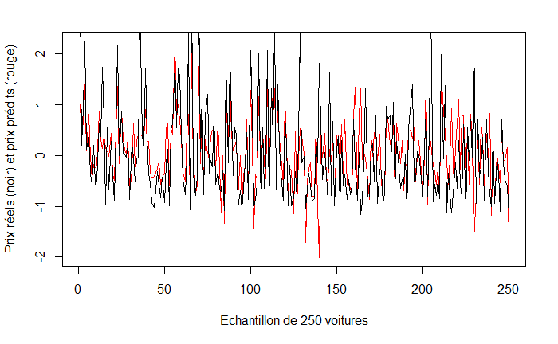

```r
plot(c(1:250),lmm.pred[1:250],type="l",col="red",xlab="Echantillon de 250 voitures",ylab = "Prix réels (noir) et prix prédits (rouge)")
lines(c(1:250),valid.df$price[1:250],col="black")
```

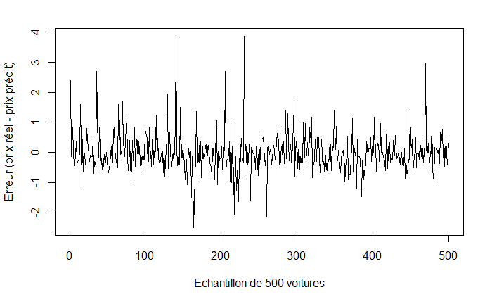

```r
#On visualise graphiquement l'erreur en se limitant à 500 cas.
plot(c(1:500),valid.df$price[1:500]-lmm.pred[1:500],type="l",col="black",xlab="Echantillon de 500 voitures",ylab = "Erreur (prix réel - prix prédit)")
```

```r
#Moyenne des erreurs :
mean(valid.df$price - lmm.pred)
```

```
[1] 0.0001757669
```

```r
#Moyenne des prix :
mean(valid.df$price)
```

```
[1] 0.001088247
```

```r
#Je dois renommer certaines variables pour appliquer le random forest, en enlevant les espaces ou caractères spéciaux.
colnames(data_final)[7] <- "manufactureralfaromeo"
colnames(data_final)[8] <- "manufacturerastonmartin"
colnames(data_final)[21] <- "manufacturerharleydavidson"
colnames(data_final)[28] <- "manufacturerlandrover"
colnames(data_final)[32] <- "manufacturermercedesbenz"
colnames(data_final)[38] <- "manufacturerNotDocumented"
colnames(data_final)[51] <- "conditionlikenew"
colnames(data_final)[52] <- "conditionNotDocumented"
colnames(data_final)[54] <- "cylinders10cylinders"
colnames(data_final)[55] <- "cylinders12cylinders"
colnames(data_final)[56] <- "cylinders3cylinders"
colnames(data_final)[57] <- "cylinders4cylinders"
colnames(data_final)[58] <- "cylinders5cylinders"
colnames(data_final)[59] <- "cylinders6cylinders"
colnames(data_final)[60] <- "cylinders8cylinders"
colnames(data_final)[61] <- "cylindersNotDocumented"
colnames(data_final)[68] <- "titlestatusclean"
colnames(data_final)[69] <- "titlestatuslien"
colnames(data_final)[70] <- "titlestatusmissing"
colnames(data_final)[71] <- "titlestatuspartsonly"
colnames(data_final)[72] <- "titlestatusrebuilt"
colnames(data_final)[73] <- "titlestatussalvage"
colnames(data_final)[79] <- "driveNotDocumented"
colnames(data_final)[82] <- "sizefullsize"
colnames(data_final)[83] <- "sizemidsize"
colnames(data_final)[84] <- "sizeNotDocumented"
colnames(data_final)[85] <- "sizesubcompact"
colnames(data_final)[90] <- "typeminivan"
colnames(data_final)[91] <- "typeNotDocumented"
colnames(data_final)[100] <- "paintcolorblack"
colnames(data_final)[101] <- "paintcolorblue"
colnames(data_final)[102] <- "paintcolorbrown"
colnames(data_final)[103] <- "paintcolorcustom"
colnames(data_final)[104] <- "paintcolorgreen"
colnames(data_final)[105] <- "paintcolorgrey"
colnames(data_final)[106] <- "paintcolorNotDocumented"
colnames(data_final)[107] <- "paintcolororange"
colnames(data_final)[108] <- "paintcolorpurple"
colnames(data_final)[109] <- "paintcolorred"
colnames(data_final)[110] <- "paintcolorwhite"
colnames(data_final)[111] <- "paintcoloryellow"
colnames(valid.df)[7] <- "manufactureralfaromeo"
colnames(valid.df)[8] <- "manufacturerastonmartin"
colnames(valid.df)[21] <- "manufacturerharleydavidson"
colnames(valid.df)[28] <- "manufacturerlandrover"
colnames(valid.df)[32] <- "manufacturermercedesbenz"
colnames(valid.df)[38] <- "manufacturerNotDocumented"
colnames(valid.df)[51] <- "conditionlikenew"
colnames(valid.df)[52] <- "conditionNotDocumented"
colnames(valid.df)[54] <- "cylinders10cylinders"
colnames(valid.df)[55] <- "cylinders12cylinders"
colnames(valid.df)[56] <- "cylinders3cylinders"
colnames(valid.df)[57] <- "cylinders4cylinders"
colnames(valid.df)[58] <- "cylinders5cylinders"
colnames(valid.df)[59] <- "cylinders6cylinders"
colnames(valid.df)[60] <- "cylinders8cylinders"
colnames(valid.df)[61] <- "cylindersNotDocumented"
colnames(valid.df)[68] <- "titlestatusclean"
colnames(valid.df)[69] <- "titlestatuslien"
colnames(valid.df)[70] <- "titlestatusmissing"
colnames(valid.df)[71] <- "titlestatuspartsonly"
colnames(valid.df)[72] <- "titlestatusrebuilt"
colnames(valid.df)[73] <- "titlestatussalvage"
colnames(valid.df)[79] <- "driveNotDocumented"
colnames(valid.df)[82] <- "sizefullsize"
colnames(valid.df)[83] <- "sizemidsize"
colnames(valid.df)[84] <- "sizeNotDocumented"
colnames(valid.df)[85] <- "sizesubcompact"
colnames(valid.df)[90] <- "typeminivan"
colnames(valid.df)[91] <- "typeNotDocumented"
colnames(valid.df)[100] <- "paintcolorblack"
colnames(valid.df)[101] <- "paintcolorblue"
colnames(valid.df)[102] <- "paintcolorbrown"
colnames(valid.df)[103] <- "paintcolorcustom"
colnames(valid.df)[104] <- "paintcolorgreen"
colnames(valid.df)[105] <- "paintcolorgrey"
colnames(valid.df)[106] <- "paintcolorNotDocumented"
colnames(valid.df)[107] <- "paintcolororange"
colnames(valid.df)[108] <- "paintcolorpurple"
colnames(valid.df)[109] <- "paintcolorred"
colnames(valid.df)[110] <- "paintcolorwhite"
colnames(valid.df)[111] <- "paintcoloryellow"
```

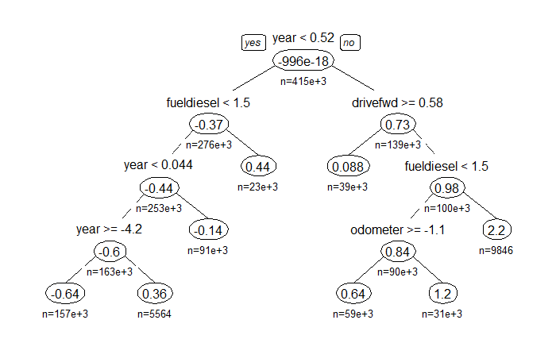

```r
#Regression tree
rt <- rpart(price~.,data=data_final,method="anova")
prp(rt,type=1,extra=1,under=TRUE,split.font=1,varlen=-10)
```

On obtient un arbre avec 8 “terminal nodes” et une profondeur maximale de 4.

```r
#Quelques métriques sur l'arbre de régression
printcp(rt)
plotcp(rt)
summary(rt)

 # create additional plots
par(mfrow=c(1,2)) # two plots on one page
rsq.rpart(rt) # visualize cross-validation results
```

[output not shown]

```
#Random forest
#très très long à compute !
rf <- randomForest(price~.,data=data_final,ntree=100,mtry=4,nodesize=5,importance=TRUE)
varImpPlot(rf,type=1)
rf.pred <- predict(rf, valid.df)
```

Résultat:

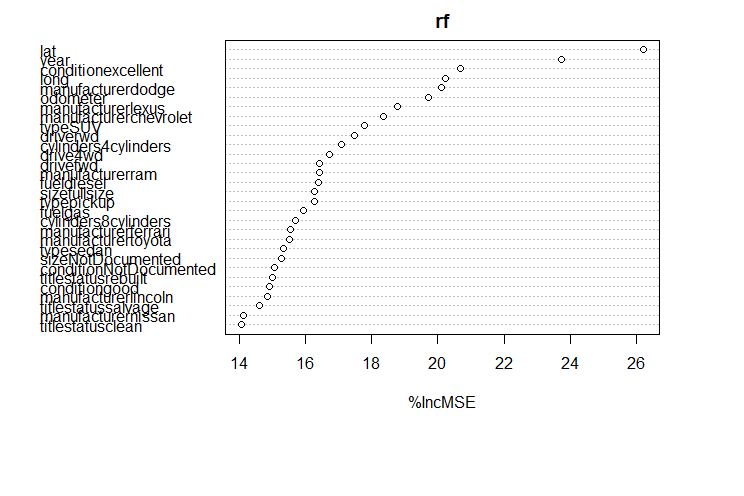